# Trabajo Final: Análisis de la Propiedad Empresarial Femenina

### Indicador: Empresas con participación de mujeres en la propiedad (% de empresas)

### Fuente de datos: Banco Mundial

### Descripción del indicador: Este dato representa el porcentaje de empresas en las que al menos una mujer forma parte de los dueños principales. Es un indicador clave para medir la equidad de género en el sector productivo y el acceso femenino a activos estratégicos.

## Lista

```
             Country Name       2017       2023
9               Argentina  57.806030        NaN
28                Bolivia  68.606232        NaN
29                 Brasil        NaN        NaN
39                  Chile        NaN        NaN
45               Colombia  66.885727  62.497063
48             Costa Rica        NaN  53.008682
50                   Cuba        NaN        NaN
59   República Dominicana        NaN        NaN
66                Ecuador  70.406807        NaN
154                México        NaN  14.872395
186                  Perú  56.577946  55.309395
195              Paraguay  66.204826  63.419483
250               Uruguay  36.953804        NaN
254             Venezuela        NaN        NaN
```

## Función: comparar los años 2017 y 2023

```
             Country Name       2017       2023     Evolucion_17_23
9               Argentina  57.806030        NaN  Dato no disponible
28                Bolivia  68.606232        NaN  Dato no disponible
29                 Brasil        NaN        NaN  Dato no disponible
39                  Chile        NaN        NaN  Dato no disponible
45               Colombia  66.885727  62.497063         Disminución
48             Costa Rica        NaN  53.008682  Dato no disponible
50                   Cuba        NaN        NaN  Dato no disponible
59   República Dominicana        NaN        NaN  Dato no disponible
66                Ecuador  70.406807        NaN  Dato no disponible
154                México        NaN  14.872395  Dato no disponible
186                  Perú  56.577946  55.309395         Disminución
195              Paraguay  66.204826  63.419483         Disminución
250               Uruguay  36.953804        NaN  Dato no disponible
254             Venezuela        NaN        NaN  Dato no disponible
```

## Gráfico 1: Participación de Mujeres en la Propiedad de Empresas (2023)

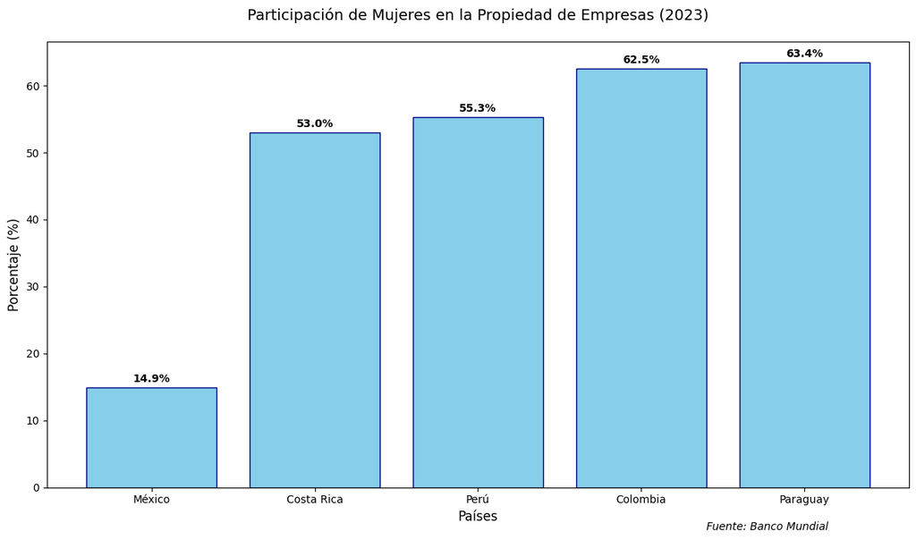

Resultados: Entre los países seleccionados que contienen información del 2023 sobre la participación de las mujeres en la propiedad de las empresas, Paraguay registra el nivel más alto de inclusión con un 63.4%, contrastando con México, que reporta el porcentaje más bajo de la muestra con solo un 14.9%.

## Gráfico 2: Tendencia de la Participación Femenina en la Propiedad de Empresas (Comparativa 2017 vs 2023)

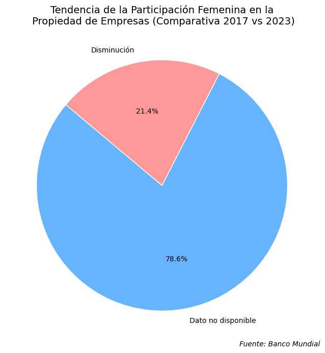